# Assignment_W2

Leandro Santos

April 6, 2018

#### LOAD KNITR AND SET OPTION TO CREATE FIGURES IN SPECIFIC DIRECTORY

```r
library(knitr)
```

```r
opts_chunk$set(fig.path = "./figure/")
```

- Load the data (i.e. read.csv())
- Process/transform the data (if necessary) into a format suitable for your analysis

#### LOAD DATA

```r
activity <- read.csv("activity.csv", header = TRUE)
```

#### TRANSFORM DATA AND CREATE DATASETS TO SUPPORT THE ANALYSIS

```r
activity$interval <- formatC(activity$interval, width = 4, flag = 0)
```

#### CREATE DATASET FOR TOTAL STEPS TAKEN PER DAY -> DAILY

```r
total <- with(activity, tapply(steps, as.Date(date), sum, na.rm=TRUE))
daily <- data.frame(names(total), as.vector(total))
names(daily) <- c("Date", "Steps")
daily$Date <-as.Date(daily$Date)
```

```r
total <- with(activity, tapply(steps, interval, mean, na.rm=TRUE))
hourly <- data.frame(names(total), as.vector(total))
names(hourly) <- c("Hours", "Steps")
hourly$Hours<-as.character(hourly$Hours)
```

- What is mean total number of steps taken per day? You can ignore the missing values.

#### MEAN OF TOTAL STEPS TAKEN PER DAY

```r
mean(daily$Steps)
```

```
## [1] 9354.23
```

- Calculate the total number of steps taken per day
- Make a histogram of the total number of steps taken each day
- Calculate and report the mean and median of the total number of steps taken per day

#### TOTAL NUMBER OF STEPS IN EACH DAY (PER DAY)

```r
daily
```

```
##          Date Steps
## 1  2012-10-01     0
## 2  2012-10-02   126
## 3  2012-10-03 11352
## 4  2012-10-04 12116
## 5  2012-10-05 13294
## 6  2012-10-06 15420
## 7  2012-10-07 11015
## 8  2012-10-08     0
## 9  2012-10-09 12811
## 10 2012-10-10  9900
## 11 2012-10-11 10304
## 12 2012-10-12 17382
## 13 2012-10-13 12426
## 14 2012-10-14 15098
```

[output cut: 47 more lines]

#### HISTOGRAM

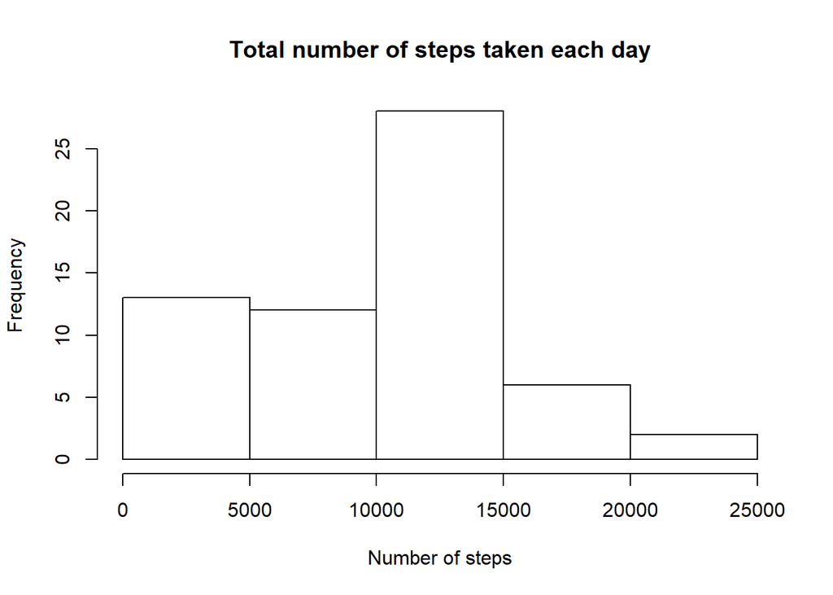

```r
hist(daily$Steps, main="Total number of steps taken each day", xlab="Number of steps")
```

#### MEAN AND MEDIAN OF STEPS TAKEN PER DAY

```r
median(daily$Steps)
```

```
## [1] 10395
```

```r
mean(daily$Steps)
```

```
## [1] 9354.23
```

- What is the average daily activity pattern?
- Make a time series plot (i.e. type = “l”) of the 5-minute interval (x-axis) and the average number of steps taken, averaged across all days (y-axis)
- Which 5-minute interval, on average across all the days in the dataset, contains the maximum number of steps?

#### DAILY ACTIVITY PATTERN

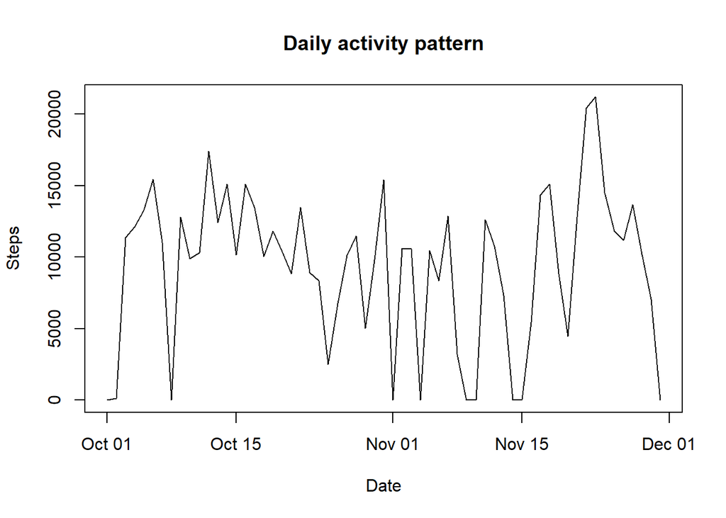

```r
with(daily, plot(Date, Steps, type="l", main="Daily activity pattern"))
```

#### TIME SERIES PLOT FOR AVERAGED 5-MINUTE INTERVAL

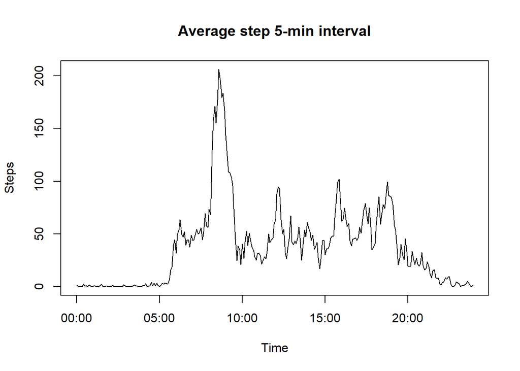

```r
with(hourly, plot(strptime(Hours, "%H%M"), Steps, type="l", xlab="Time", main = "Average step 5-min interval"))
```

#### HIGHER 5-MINUTE INTERVAL

```r
hourly$Hours[which.max(hourly$Steps)]
```

```
## [1] "0835"
```

- Calculate and report the total number of missing values in the dataset (i.e. the total number of rows with NAs)
- Devise a strategy for filling in all of the missing values in the dataset. For example, you could use the mean/median for that day, or the mean for that 5-minute interval, etc.
- Create a new dataset that is equal to the original dataset but with the missing data filled in.
- Make a histogram of the total number of steps taken each day and Calculate and report the mean and median total number of steps taken per day.
- Do these values differ from the estimates from the first part of the assignment? What is the impact of imputing missing data on the estimates of the total daily number of steps?

#### NUMBER OF MISSING VALUES

```r
sum(is.na(activity$steps))
```

```
## [1] 2304
```

#### REPLACING MISSING VALUES WITH 5-MIN INTERVAL MEAN

```r
activity$steps <- with(activity, ave(steps, interval, FUN = function(x) replace(x, is.na(x), mean(x, na.rm=TRUE))))
```

#### RECREATING SUPPORT DATASET: FOR TOTAL STEPS TAKEN PER DAY -> DAILY

```r
total <- with(activity, tapply(steps, as.Date(date), sum, na.rm=TRUE))
daily <- data.frame(names(total), as.vector(total))
names(daily) <- c("Date", "Steps")
daily$Date <-as.Date(daily$Date)
```

```r
total <- with(activity, tapply(steps, interval, mean, na.rm=TRUE))
hourly <- data.frame(names(total), as.vector(total))
names(hourly) <- c("Hours", "Steps")
hourly$Hours<-as.character(hourly$Hours)
```

#### NEW HISTOGRAM

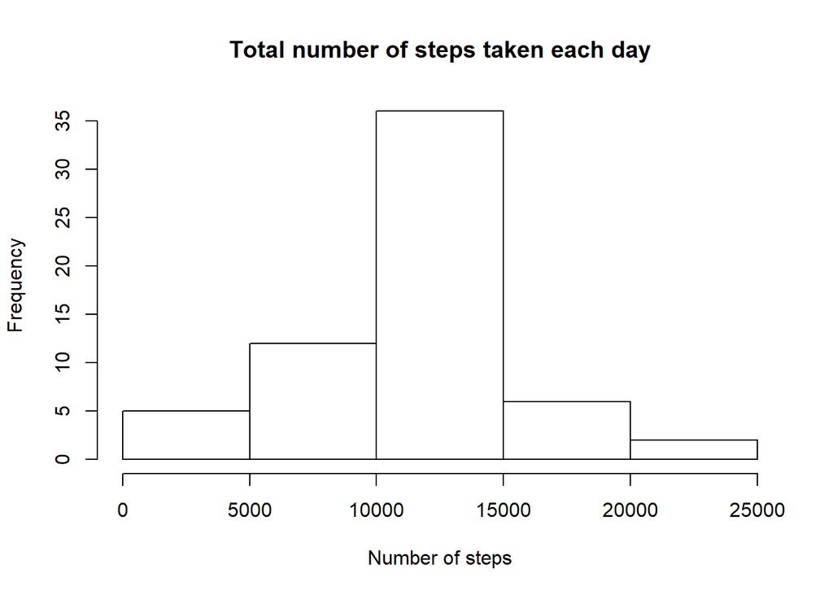

```r
hist(daily$Steps, main="Total number of steps taken each day", xlab="Number of steps")
```

#### NEW MEAN AND MEDIAN OF STEPS TAKEN PER DAY

```r
median(daily$Steps)
```

```
## [1] 10766.19
```

```r
mean(daily$Steps)
```

```
## [1] 10766.19
```

#### Result: We can notice a difference from previous mean and median. Now both are equals and according to the histogram, values seems to be more normally distributed.

- Create a new factor variable in the dataset with two levels - “weekday” and “weekend” indicating whether a given date is a weekday or weekend day.
- Make a panel plot containing a time series plot (i.e. type = “l”) of the 5-minute interval (x-axis) and the average number of steps taken, averaged across all weekday days or weekend days (y-axis).

#### CREATING FACTOR DATABASE “WEEKLY” WITH AVG PER INTERVAL AND MAKING A PLOT

[figure not shown]

```r
activity$week <- ifelse(weekdays(as.Date(activity$date)) %in% c("Saturday", "Sunday"), "weekend", "weekday")
weekly <- aggregate(steps ~ week+interval, activity, mean)
library(ggplot2)
q <- ggplot(weekly, aes(interval, steps, group=1))
q+geom_line()+facet_grid(.~week)
```